# An exploration of factors for shared bike's usage change

## by Fanlaizhangkou24/7

This investigation uses the Ford GoBike System Data of 2020 Apr used during this exploration is published on https://www.lyft.com/.

```python
# import all packages and set plots to be embedded inline
import pandas as pd
import numpy as np
import random
import matplotlib.pyplot as plt
import seaborn as sb
%matplotlib inline
```

> Load in your dataset and describe its properties through the questions below. Try and motivate your exploration goals through this section.

```python
bkdf = pd.read_csv('baywheels.csv')
bkdf.info()
```

```
<class 'pandas.core.frame.DataFrame'>
RangeIndex: 84259 entries, 0 to 84258
Data columns (total 13 columns):
ride_id               84259 non-null object
rideable_type         84259 non-null object
started_at            84259 non-null object
ended_at              84259 non-null object
start_station_name    53434 non-null object
start_station_id      53434 non-null float64
end_station_name      51858 non-null object
end_station_id        51858 non-null float64
start_lat             84259 non-null float64
start_lng             84259 non-null float64
end_lat               84117 non-null float64
end_lng               84117 non-null float64
member_casual         84259 non-null object
dtypes: float64(6), object(7)
memory usage: 8.4+ MB
```

```python
# check member types
bkdf.member_casual.unique()
```

```
array(['casual', 'member'], dtype=object)
```

```python
# check member types
bkdf.rideable_type.unique()
```

```
array(['electric_bike', 'docked_bike'], dtype=object)
```

```python
# fix date format
bkdf['started_at'] = pd.to_datetime(bkdf['started_at'])
bkdf['ended_at'] = pd.to_datetime(bkdf['ended_at'])
```

```python
# add new column duration in minutes¶
bkdf['duration_minute']=(bkdf.ended_at-bkdf.started_at).astype('timedelta64[m]')
```

```python
# drop uninterested column
bkdf.drop(['start_station_name','end_station_name','start_station_id', 'end_station_id','start_lng','start_lat','end_lng','end_lat'], axis=1,inplace=True)
```

```python
np.sum(bkdf.isnull())
```

```
ride_id            0
rideable_type      0
started_at         0
ended_at           0
member_casual      0
duration_minute    0
dtype: int64
```

### This dataset includes ids of bike rides, the start - end time information, the member and rideable bike types. My main interests in this dataset is how the start time('started_at) relate to the bike usage. I think the total number, bike type('rideable_type') and user type('member_casual') might be the main features that helps the investigation.

## Univariate Exploration

*1. What is the bike usage of each bike type?*

```
Text(0.5,0,'rideable bike type')
```

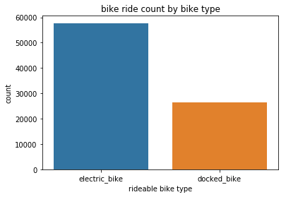

```python
sb.countplot(data = bkdf, x = 'rideable_type')
plt.title('bike ride count by bike type')
plt.xlabel('rideable bike type')
```

**Comment:** Docked bikes have been hired nearly 30000 times in the sample month. The amount of electric bikes was hired about twice as often.

*2. How active is each type of user?*

```
Text(0.5,0,'user type')
```

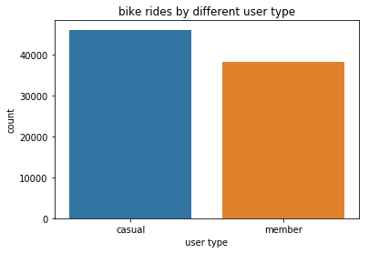

```python
sb.countplot(data = bkdf, x = 'member_casual')
plt.title('bike rides by different user type')
plt.xlabel('user type')
```

*3. What is the bike usage on each day of week?*

```python
# add new column 'start day of week'
bkdf['start_dow'] = bkdf.started_at.dt.dayofweek
```

```
Text(0.5,0,'start day of week')
```

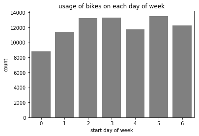

```python
sb.countplot(data = bkdf, x = 'start_dow',color='grey')
plt.title('usage of bikes on each day of week')
plt.xlabel('start day of week')
```

**Comment:** The chart shows the bikes get most heavily used on Wednesdays,Thursdays and Saturdays. On average, Monday shows the lowest bike usage.

*4. What is the bike usage in each hour?*

```python
# add new column 'start hour'
bkdf['start_hour'] = bkdf.started_at.dt.hour
```

```
Text(0.5,0,'start day of week')
```

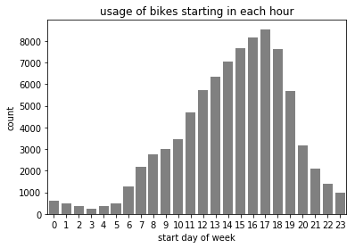

```python
sb.countplot(data = bkdf, x = 'start_hour',color='grey')
plt.title('usage of bikes starting in each hour')
plt.xlabel('start day of week')
```

**Comment:** The bikes get used most often between 16:00 - 18:00 and least often between 2:00 - 5:00.

*5. What is the bike usage by different types user who use different bikes?*

```
Text(0.5,0,'rideable bike type')
```

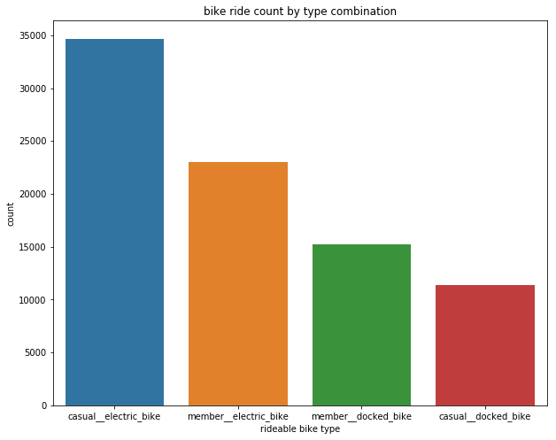

```python
# add new column 'start hour'
bkdf['type_comb'] = bkdf.member_casual+'__'+bkdf.rideable_type
plt.figure(figsize=(10, 8))
sb.countplot(data = bkdf, x = 'type_comb')
plt.title('bike ride count by type combination')
plt.xlabel('rideable bike type')
```

**Comment:** Casual users who use electric bike are the most active users, member users also prefer electric bikes. Docked bikes are not as popular.

*6. What is the average riding time for each type of bike user?*

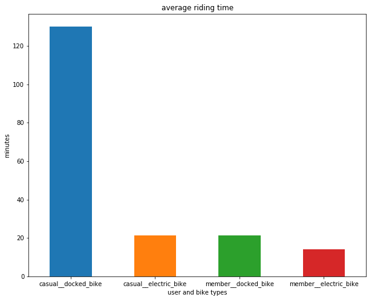

```python
data = bkdf.groupby('type_comb').mean().duration_minute
data.plot(kind = 'bar',figsize=(10,8))
plt.title('average riding time')
plt.xlabel('user and bike types')
plt.ylabel('minutes')
plt.xticks(rotation = 0)
```

**Comment:** Casual users who use docked bike have the longest average riding time longer than 120 minutes. Member users who use electric bike have the shortest average riding time which is less than 20 minutes. Other user ride around 20 minutes in average.

### To visualize this pattern, I extracted the start day of week and start hours from the started date. I also changed the date format from timespame to data objects to be able to get the days and hours also to get rid of over detailed time information. I combined the user type and bike type for calculating the average trip duration.

## Bivariate Exploration

*1. How the bike usage change depending on the day?*

```
Text(0.5,0,'start day of week')
```

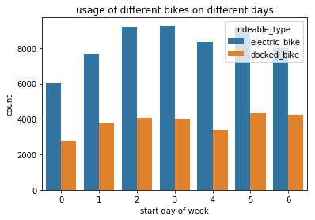

```python
sb.countplot(data = bkdf, x = 'start_dow', hue = 'rideable_type')
plt.title('usage of different bikes on different days')
plt.xlabel('start day of week')
```

**Comment:** The bike usage on each day of week have very similar patterns to the charts plotted in the univariate exploration.

*2. How the bike usage change depending on the starting hours?*

```
Text(0.5,0,'start hour')
```

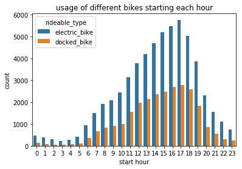

```python
sb.countplot(data = bkdf, x = 'start_hour', hue = 'rideable_type')
plt.title('usage of different bikes starting each hour')
plt.xlabel('start hour')
```

**Comment:** Both types of bikes get used most often between 16:00 - 18:00 and least often between 2:00 - 5:00.

```
Text(0.5,0,'start day of week')
```

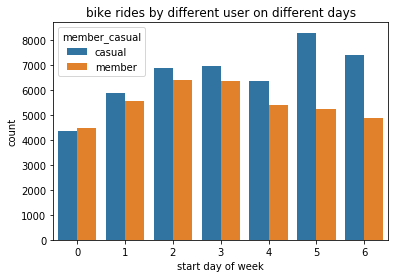

```python
sb.countplot(data = bkdf, x = 'start_dow', hue = 'member_casual')
plt.title('bike rides by different user on different days')
plt.xlabel('start day of week')
```

**Comment:** By average, the difference between bike rides by both types of user doesn't easily go beyond 1000 on weekdays. However the amount of bike rides by casual users gets significantly higher on weekends.

*4. How the bike usage change depending on the starting hours?*

```
Text(0.5,0,'start hour')
```

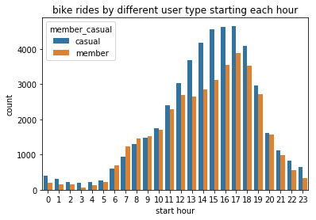

```python
sb.countplot(data = bkdf, x = 'start_hour', hue = 'member_casual')
plt.title('bike rides by different user type starting each hour')
plt.xlabel('start hour')
```

**Comment:** Casual users are normally more active than member users, expecially between 13:00 - 15:00. However this situation gets reversed between 6:00 - 10:00.

### It was intereting to me that the the ratio of two types of bike stayed roughly the same even though the most active days and hours are different to different types of user.

## Multivariate Exploration

*1. How the bike usage gets influenced by the starting day and hour?*

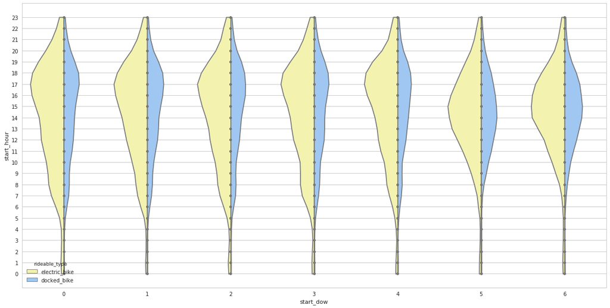

```python
sb.set(style="whitegrid", palette="pastel", color_codes=True)
plt.figure(figsize=(20, 10))
npArange = np.arange(0,23+1,1)
plt.yticks(npArange)
sb.violinplot(y="start_hour",x="start_dow", hue="rideable_type",
              gridsize = 24,
              scale = 'count',cut = 0, split=True, inner="point",
               palette={"electric_bike": "y", "docked_bike": "b"},
               data=bkdf)
```

**Comment:** The ratio of two types of bike stays roughly the same on each day of week and each hour. During week days, the most popular starting hours for both bypes of bike are between 16:00 - 18:00. On weekends, the most popular starting hours are between 14:00 - 17:00.

*2. How does users' activeness change depending on the starting day and hour*

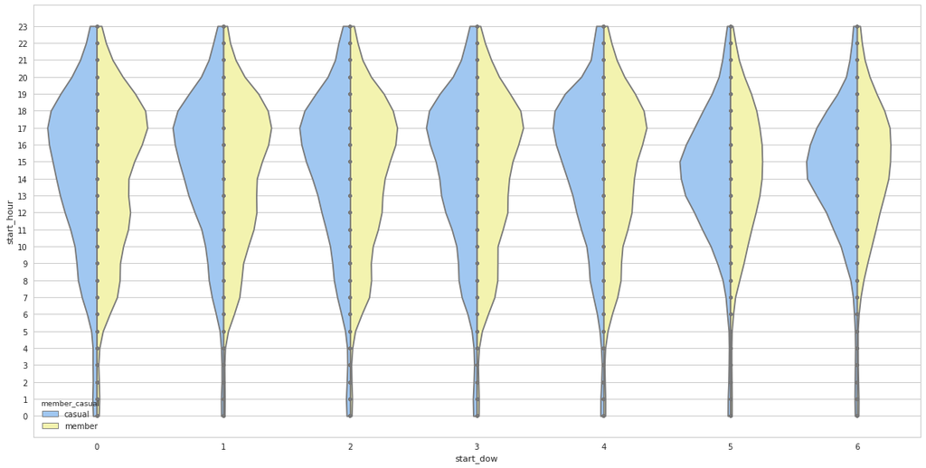

```python
sb.set(style="whitegrid", palette="pastel", color_codes=True)
plt.figure(figsize=(20, 10))
npArange = np.arange(0,23+1,1)
plt.yticks(npArange)
sb.violinplot(y="start_hour",x="start_dow", hue="member_casual",
              gridsize = 24,
              scale = 'count',cut = 0, split=True, inner="point",
               palette={"member": "y", "casual": "b"},
               data=bkdf)
```

**Comment:** The pattern shows a similar trend as the previous one except there is an bike use increase at 12:00 by member users.

### It is interesting that both types of users with different rideable bike types seemed to have their activeness related to the starting hour and day hugely and electric bikes were preferred by both types of user.